# Space-time-age Trend Modeling: A Bayesian Hierarchical Model

Ta-Chou Ng (dachuwu@gmail.com)

2019/08/15

### Overview

This report demonstrates our data and current method modeling the space-time-age trend of health metrices in Taiwan. We use prevalent counts of lung cancer as an example. The content is comprised of six sections, including

1. Data
2. Model
3. Prior Predictive Check
4. Sampling
5. Diagnostics
6. Evaluation

### I. Data

**[Figure 1] Taiwan Administrative Hierarchy**

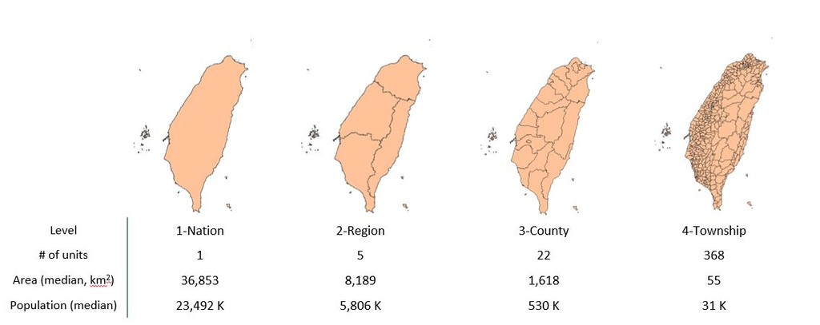

Because the data is often sparse, models are needed to interpolate unobserved data points for comprehensive estimation of disease burden. In addition to age/sex/township/year, external covariates are also used to enhance prediction power. They are often township-specific covariates, such as urbanization level and number of hospitals.

#### Example Dataset: Lung Cancer Prevalent Counts

This dataset contains prevalent counts of lung cancer patients (regardless of stage) from 2000 to 2015 in each age-sex-township-year (A-S-T-Y) stratum. 10 basic variables and their formats are listed in table 1. The dataset in .csv format can be found in attachment. In brief, the dependent variable is the prevalent count of lung cancer (**Y_obs**) stratified by age-sex-town-year. Higher-level administrative division (**County**, **Region**), additional covariates (**n_hos**, **urbanicity**), and offset (**population**) are also included.

**[Table 1]**

| Name | Description | Content |
| --- | --- | --- |
| **age** | Age group (**A**), ordinal | “[0,5)”, “[5,10)”,…,“[85,Inf)” |
| **sex** | Sex (**S**), categorical | “M”, “F” |
| **town** | Township (**T**), level-4 adminstrative, categorical | 4-digit code: “0101”,…,“9104” |
| **county** | County, level-3 adminstrative, categorical | 2-digit code: “01”,…,“91” |
| **region** | Region, level-2 adminstrative, categorical | “N”,“C”,“S”,“E”,“I” |
| **year** | Year (**Y**), integer | 2000~2015 |
| **pcount** | Observed prevalent count in the **A-S-T-Y** stratum | >= 0 |
| **population** | Total population in the **A-S-T-Y** stratum | >= 0 |
| **n_hos** | Number of hospital in the **T-Y** stratum | >= 0 |
| **urb** | Urbanization level of the **T** stratum, categorical | 1~7 |

The continuous variables are centered or standardized, and categorical variables are translated into integer indicators for model implementation. The derived variables are listed below.

**[Table 2]**

| Name | Description | Class |
| --- | --- | --- |
| **Xage** | Midpoint of **age** group, centered at 45 | numeric |
| **Xyear** | **year**, centered at 2008 | numeric |
| **Xtown** | indicator of **town** | integer |
| **Xcounty** | indicator of **county** | integer |
| **Xregion** | indicator of **region** | integer |
| **Xurb** | indicator of **urb** | integer |
| **Xnhos** | z score of **n_hos** | numeric |
| **lpop** | logarithm of **population** | numeric |

Here, we present the first several samples of the demo file.

[output not shown]

```r
df <- readRDS("../exp11_lung_cancer.RDS")
head(df)
```

# II. Model

The current model structure is adapted from (Danaei, G., et al. 2011), but applied to prevalent count data. We also stratify the analysis by **Sex**. The likelihood of an observed count in age $h$, township $j$, and year $t$ is

$$y_{h,j,t} \sim Poisson(\mu_{h,j,t}) \\
\mu_{h,j,t} = a_j + b_j t + \boldsymbol{S}(h) + \boldsymbol{\beta x}_{h,j,t}.$$
$a_j$ and $b_j$ are the intercept and slope of linear time trend in township $j$. $\boldsymbol{S}(h)$ is the smoothed age effect using B-spline basis. $\boldsymbol{\beta x}_{h,j,t}$ is the linear predictor of covariate effect.

### Time-space Effect

Currently, we only considered linear time trend for time-space effect, which is modeled according to the administrative hierarchy. The intercept $a_j$ is composed of township($\text{twn}$)-, county($\text{cty}$)-, and nation($\text{nat}$)-specific intercept, so is the slope $b_j$.
$$a_j = a_{j}^{\text{twn}} + a_{\text{cty}[j]}^{\text{cty}} + a^{\text{nat}}$$
$$b_j = b_{j}^{\text{twn}} + b_{\text{cty}[j]}^{\text{cty}} + b^{\text{nat}}$$
Except for $a^{\text{nat}}$ and $b^{\text{nat}}$, each intercept and slope component is given a zero-mean normal prior with standard deviation $\kappa$.
$$a_{j}^{\text{twn}} \sim N(0, \kappa_{a}^{\text{twn}}), \ \
a_{\text{cty}[j]}^{\text{cty}} \sim N(0, \kappa_{a}^{\text{cty}})$$
$$b_{j}^{\text{twn}} \sim N(0, \kappa_{b}^{\text{twn}}), \ \
b_{\text{cty}[j]}^{\text{cty}} \sim N(0, \kappa_{b}^{\text{cty}})$$

And $\kappa$’s are given half-normal hyper-priors with parameters $\sigma^{intercept}$ and $\sigma^{slope}$. The value of $\sigma^{intercept}$ and $\sigma^{slope}$ were assigned based on prior predictive check for the reasonable outcome range

$$\kappa_a^* \sim \text{Half-Normal}(0,\sigma^{intercept})$$
$$\kappa_b^* \sim \text{Half-Normal}(0,\sigma^{slope})$$

### Age Effect

We use B-spline basis to model smoothed age effect. The order $q$ is set to 3 (cubic splines) and the number knots $k$ is 5 (evenly spaced over the midpoints of age groups).
$$\boldsymbol{S}(h) = \sum_{m=1}^{k+2q-3}\gamma_m \boldsymbol{B_{m,q}}(h)$$
where $\boldsymbol{B_{m,q}}(h)$ is defined recursively (see reference [2]). $\gamma$’s are given regularized normal prior (see reference [3]).
$$\gamma_1 \sim N(0,\kappa_s) \\ \gamma_m \sim N(\gamma_{m-1},\kappa_s)$$
for $m = 2, ...,k+2q-3$ .

$$\kappa_s \sim \text{Half-Normal}(0,\sigma^{{spline}})$$

### Covariate Effect

So far, we have considered only one covariates: the urbanization level ($urb$) which is is categorical with 7 groups. We constrained the fourth parameter $\beta_4$ to be zero in order to ensure identifiability. Other $\beta$’s are given standard normal prior.
$$\boldsymbol{\beta x}_{h,j,t} = \sum_{r=1}^7\beta_r^{urb}I\{x^{urb}_{j,t} =r\}, \ \ where\ \ \beta^{urb}_4=0$$

# III. Prior Predictive Check

To improve sampling efficiency, we conduct prior predictive analysis to help assign practical prior distributions for the following hyper-parameters,

$\sigma^{intercept}$, determining the prior scale of varying intercept effect ($a_{\text{twn}}$, $a_{\text{cty}}$, $a_{\text{nat}}$, $\beta^{urb}$)

$\sigma^{slope}$, determining the prior scale of varying time slope effect ($b_{\text{twn}}$, $b_{\text{cty}}$, $b_{\text{nat}}$)

$\sigma^{{spline}}$, determining the prior scale of varying B-spline regression coefficient ($\gamma$)

### 1. Scale in linear time trend (intercept)

$\sigma^{intercept}$ determines the hyper prior for the scale parameters of town-, county-, nation- specific intercepts ($\kappa_{a}^{\text{twn}}$, $\kappa_{a}^{\text{cty}}$, $\kappa_{a}^{\text{nat}}$). That is, the variation of the intercepts in linear time trend. Given that prevalence rate must be bounded between 0 and 1, simulated data points (light blue dots) exceed the limit (black horizontal line) is unreasonable. We choose $\sigma^{intercept} = 0.5)$ where the of-the-limit points are less common, yet the prior still represents good non-informativeness. The observed data points are shown in red.

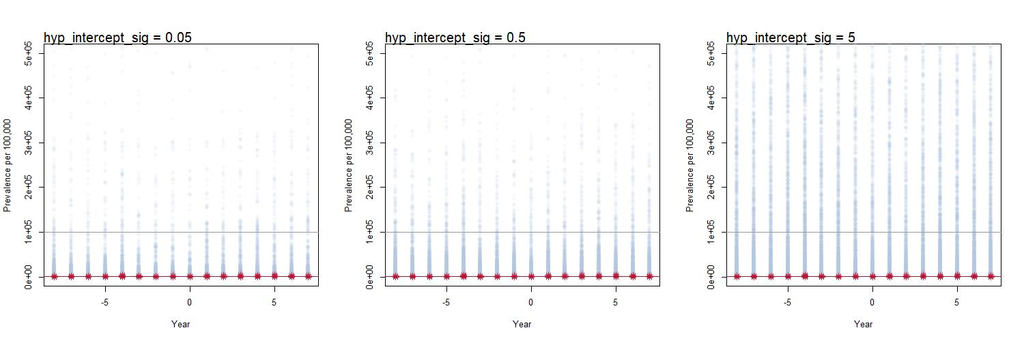

### 2. Scale in linear time trend (slope)

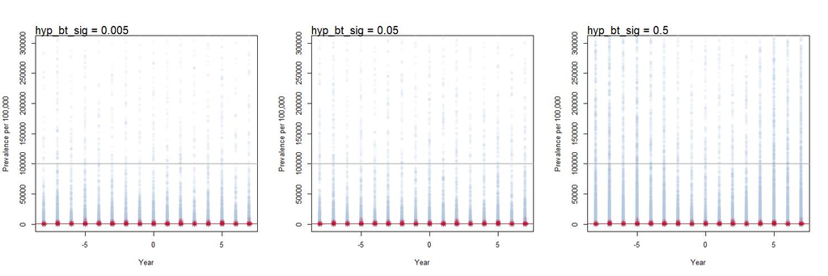

### 3. Scale in age pattern

Likewise, we choose $\sigma^{spline} =1$ which determines the hyper prior for the scale parameters of B-spline basis coefficients ($\kappa_s$)

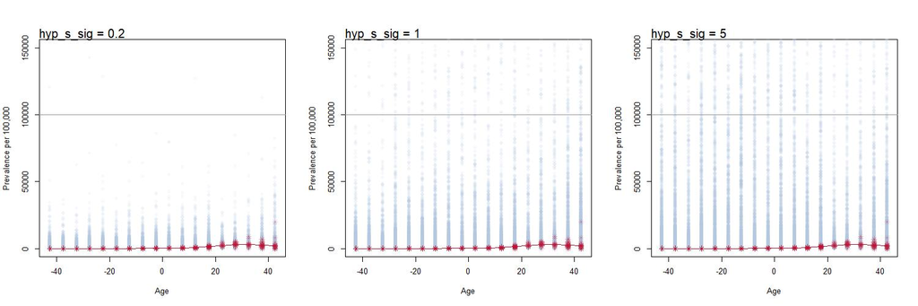

Note that the baseline setting (also the final setting) of the prior predictive simulation is

$$\begin{align}
&a^{\text{nat}} \sim \text{Normal}(-5,0.5) \\
&b^{\text{nat}} \sim \text{Normal}(0,0.05) \\
&\kappa_a^* \sim \text{Half-Normal}(0,0.5), \ \ for \ * = \text{twn, cty} \\
&\kappa_b^* \sim \text{Half-Normal}(0,0.05), \ \ for \ * = \text{twn, cty} \\
&\kappa_s^{\ } \sim \text{Half-Normal}(0,1)
\end{align}$$

# IV. Sampling

We implented this model in *rstan*. The R/stan codes and resulting rstanfit object can be found in the attachments. We have applied non-centered parameterization as recommended by ref [5]. The settings of Hamiltonion Monte Carlo sampling are listed below.

**[Table 2]**

[output not shown]

# V. Diagnostics

We checked several HMC diagnostics according to ref [6], and trace plots of model parameters.

### Divergences, maximum tree-depth, and BFMI

```r
fit <- readRDS("../mod_01_fitted.RDS")
check_divergences(fit)
```

```
0 of 800 iterations ended with a divergence.
```

```r
check_energy(fit)
```

```
E-BFMI indicated no pathological behavior.
```

```r
check_treedepth(fit)
```

```
200 of 800 iterations saturated the maximum tree depth of 15 (25%).
Try increasing 'max_treedepth' to avoid saturation.
```

```r
get_elapsed_time(fit)
```

```
        warmup   sample
chain:1 362247 160424.0
chain:2 223647  97420.2
chain:3 333561  56632.3
chain:4 219606  95351.6
```

We found no divergent transitions in our samples, and the e-BFMI’s (estimated Bayesian fraction of missing information) showed no pathological behavior. However, there are 200 samples reached the maximum tree-depth when sampling, which are all from chain 1. We also found that chain 1 had significantly longer sampling time than other chains.

### Rhat and effective sample size

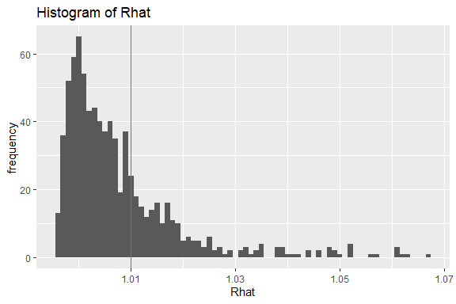

```r
pars <- fit@model_pars
exld <- c("a_c_til","a_t_til","b_t_c_til","b_t_t_til","s_til",
          "lmu","lp__","a_urb_sub") # exclude derived parameters
fit.sum <- summary(fit, pars=setdiff(pars, exld))$summary
qplot(fit.sum[,"Rhat"],binwidth=.001)+
  geom_vline(xintercept=1.01, color="orangered")+
  labs(x="Rhat", y="frequency", title= "Histogram of Rhat")
```

The recommended Rhat should be less than 1.01 (red vertical line, ref [6]) . The above histogram indicates that some parameters have discordant within- and between-chain estimates.

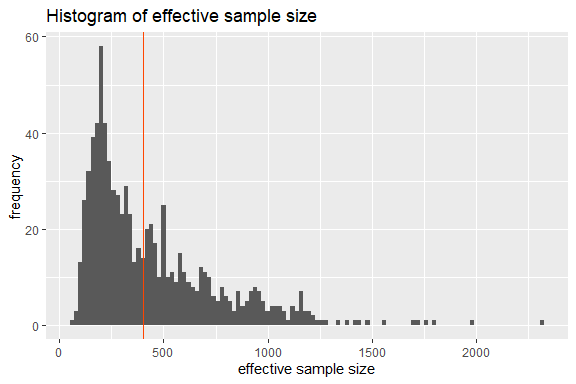

```r
qplot(fit.sum[,"n_eff"],binwidth=20)+
  geom_vline(xintercept=400, color="orangered")+
  labs(x="effective sample size", y="frequency", title= "Histogram of effective sample size")
```

The recommended effective sample size is 100 for each chain (red vertical line). The above histogram shows that about half of estimated parameters did not meet this criteria.

### Traceplot and scatter plots

Here, we only show diagnostic plots selectively. Please refer to the attached file for the rest. The traceplots and scatter plots of varying intercepts are shown below. $a^{\text{nat}}$ = `a_n`. $a^{\text{cty}}$ = `a_c`. $a^{\text{twn}}$ = `a_t`.

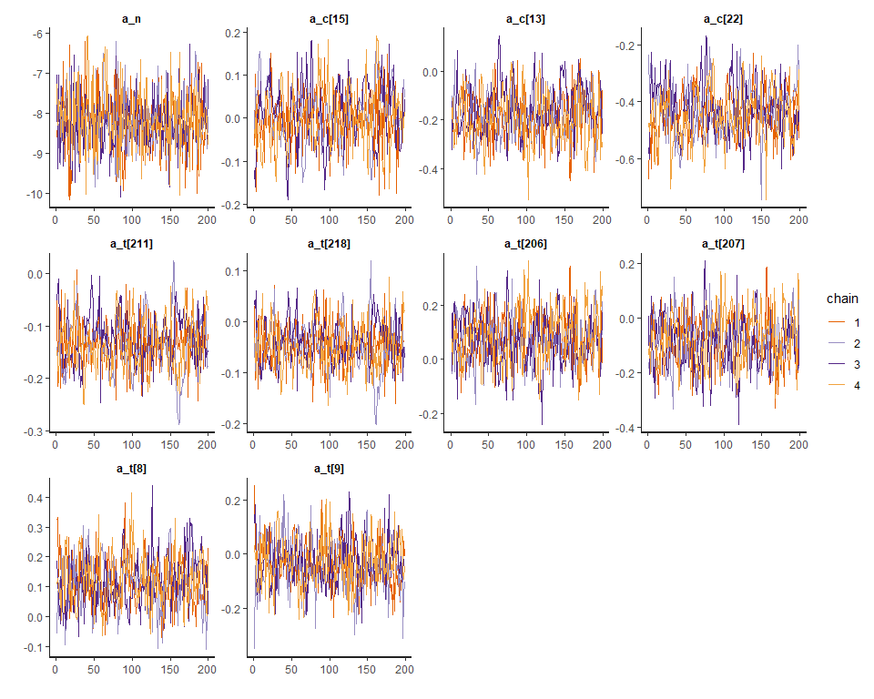

```r
traceplot(fit, pars=c("a_n","a_c[15]","a_c[13]","a_c[22]","a_t[211]","a_t[218]","a_t[206]","a_t[207]","a_t[8]","a_t[9]"))
```

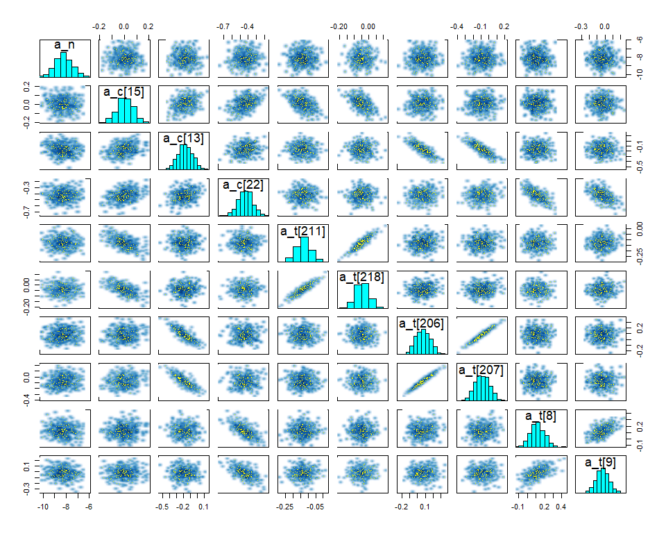

```r
pairs(fit, pars=c("a_n","a_c[15]","a_c[13]","a_c[22]","a_t[211]","a_t[218]","a_t[206]","a_t[207]","a_t[8]","a_t[9]"))
```

Transitions hitting the maximum tree-depth are marked by yellow points in above scatter plots. These showed that chain 1 failed to explore the sample space, particularly at the center area.

The followings are the diagnostic plots for B-spline regression coefficients for age pattern, $\gamma$ (`s`). Because of regularized priors on $\gamma$’s, they are linearly correlated in the scatter plots. However, we haven’t yet understand why the last coefficient $\gamma_{8}$ (`s[8]`) looks independent from others.

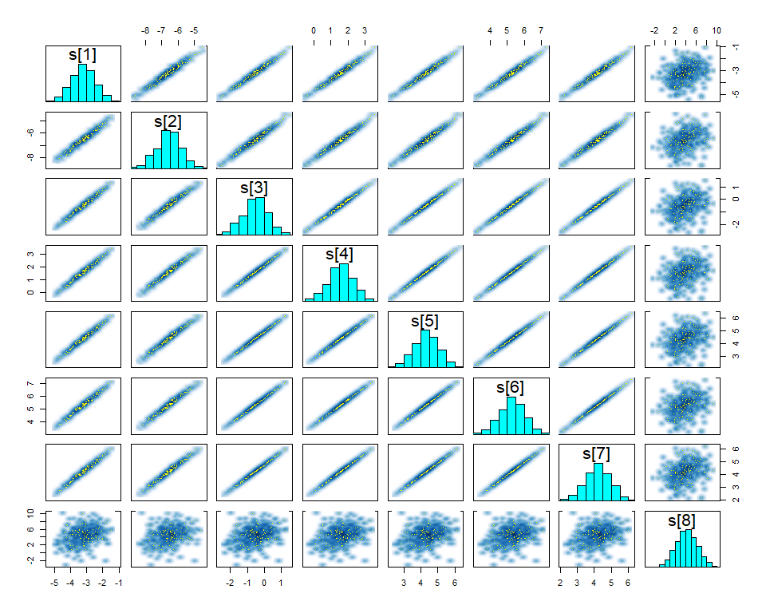

```r
pairs(fit, pars = "s")
```

# VI. Evaluation

There are many possible ways and aspects to evaluate the resulting posterior samples. For convenience, samples of the mean ($\mu_{h,j,t}$) are used for the following inference. Hence, the uncertainty interval refers to uncertainty of the mean, rather than true outcome space. We examined the consistency of predicted/observed time trend and age pattern by each geographic level. The results are shown selectively. Please refer to the attachments for the remaining.

### 1. Observed vs. fitted prevalent count

The overall model fitness is presented by the scatter plot of observed versus fitted data points.

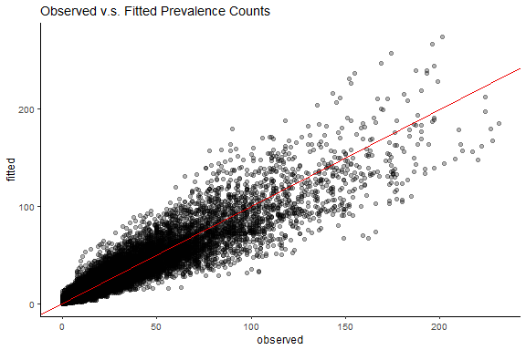

The predicted values are generally consistent with observed values (attracted to the diagonal). The residuals grows larger with the observed value, due to the property of generalized linear model.

### 2. Time trend

#### 2.1 Nation

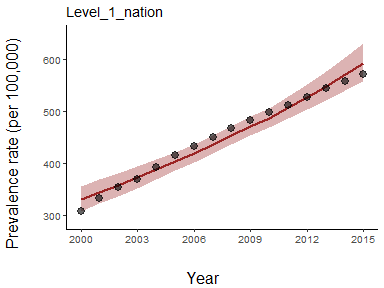

The predicted nation-level time trend is close to data, except that a slight concave trend is not captured.

#### 2.2 County: Taipei, Hsinchu, Kinmen

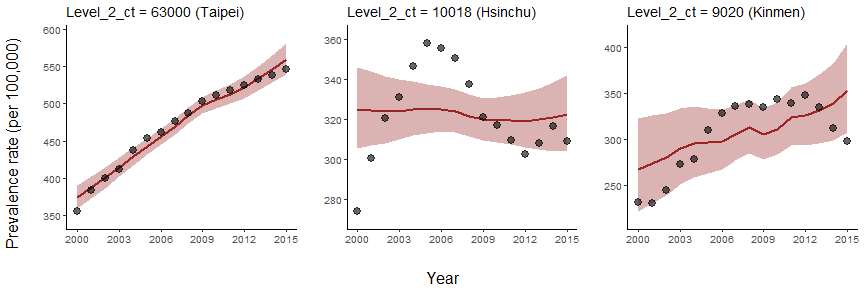

Moving into county-level, here we showed some extreme cases after examining results for every county. *Taipei* and *Hsinchu* are urban cities with high and dense population, while *Kinmen* is a remote county (not at the mainland Taiwan) with small population. The time trend is fitted better in *Taipei* than the other two ( *Hsinchu*, *Kinmen*). In *Hsinchu*, the fitted trend does not meet the fluctuating magnitude, while it fails to capture the concave shape in *Kinmen*.

#### 2.3 Town: Taipei(Songshan/Wenshan), Hsinchu(East/North), Kinmen(Kinnin/Leiyu)

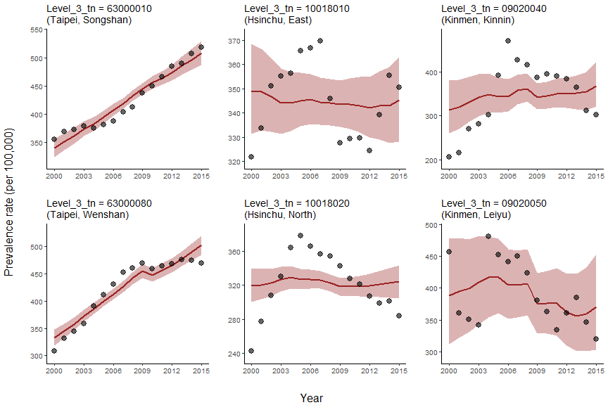

At township-level, we found more inconsistencies between observed and fitted trend, especially when non-linearity exists.

### 3. Age pattern

In terms of age patterns, the fitted trends are rather consistent with observed data.(shallow points indicate zero observed count)

#### 3.1 Nation

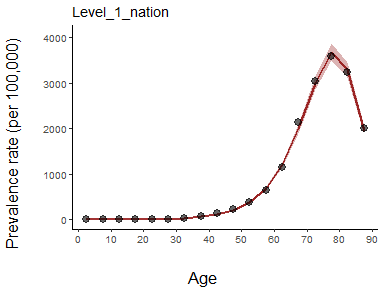

#### 3.2 County: Taipei, Hsinchu, Kinmen

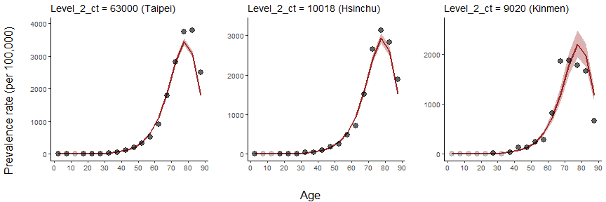

#### 3.3 Town: Taipei(Songshan/Wenshan), Hsinchu(East/North), Kinmen(Kinnin/Leiyu)

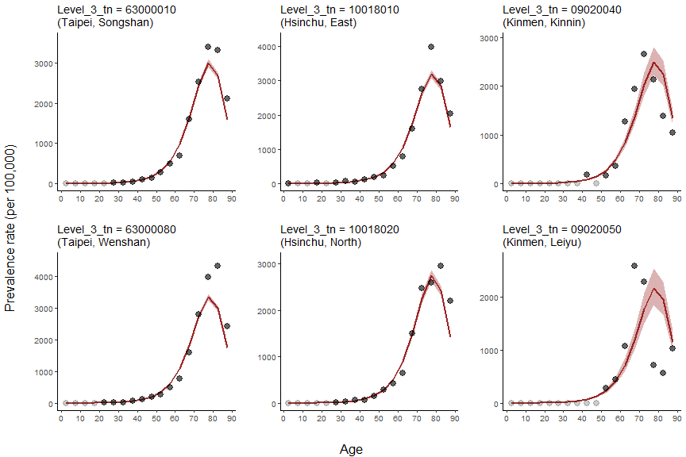

### References

1. Danaei, G., et al. (2011). “National, regional, and global trends in systolic blood pressure since 1980: systematic analysis of health examination surveys and epidemiological studies with 786 country-years and 5.4 million participants.” Lancet 377(9765): 568-577.
2. Wood SN. (2006). Generalized additive models: an introduction with R. Boca Raton, FL: CRC Press.
3. https://mc-stan.org/users/documentation/case-studies/splines_in_stan.html
4. Gelman, A. (2006). Prior distributions for variance parameters in hierarchical models (comment on article by Browne and Draper). Bayesian Anal. 1 , no. 3, 515–534.
5. https://mc-stan.org/users/documentation/case-studies/divergences_and_bias.html
6. https://mc-stan.org/misc/warnings.html
7. https://mc-stan.org/users/documentation/case-studies/weakly_informative_shapes.html